# Flexible Damage Functions

Author

James Rising, Sebastian Cadavid Sanchez, Climate Impact Lab

Published

April 30, 2026

## 0.1 Agriculture: Cassava Country

Flexible damage function parameters at the Country level.

**Change in cassava yields (log change in yields) under full adaptation**

**Outcome units:** `physical` — log change in cassava yield (population-weighted to country)

$$D_{it} = (\alpha_i T_t + \beta_i T_t^2) \cdot Y_{it}^{\gamma}$$

where $\gamma$ is the income elasticity (fitted globally), $\alpha_i$ is the linear coefficient, and $\beta_i$ is the quadratic coefficient.

# 1 Global Estimation

## 1.1 Income Elasticity Estimation

The income elasticity $\gamma$ is estimated using a fixed-effects regression:

$$y_{it} = \gamma \cdot \log(Y_{it}) + \mu_{g(i,T)} + \nu_t + \varepsilon_{it}$$

where $\mu_{g(i,T)}$ are region-by-temperature-bin fixed effects and $\nu_t$ are year fixed effects.

Table 1: Income Elasticity (Gamma) Estimation Results

| Statistic | Value |
| --- | --- |
| Income elasticity ($\gamma$) | 0.0272 |
| Standard error | 4.92e-03 |
| 95% CI | [0.0176, 0.0369] |
| R-squared | 0.5994 |
| Observations | 39,622,666 |
| Regions | 127 |
| Gamma quantiles | 19 |

# 2 Parameter Distributions

## 2.1 8-Panel Summary

Row 1: gamma, alpha, beta, rsqr1. Row 2: rho, zeta, eta, rsqr2.

```
Using median gamma: 0.027248, 127 rows (of 2,413 total)
```

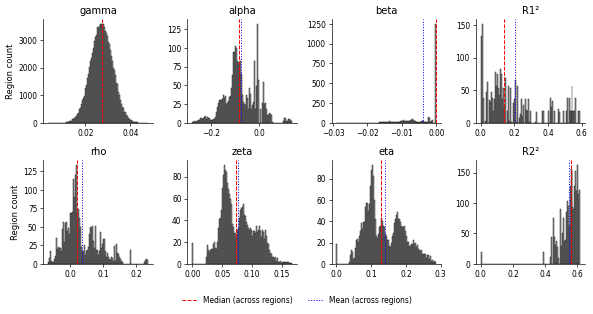

Figure 1: Distribution of Regional Parameters

## 2.2 Projection Equation and Parameter Definitions

The estimated parameters are used to project damages via Monte Carlo sampling:

$$D_{it}^k = (\hat{\alpha}_{ik} T_t + \hat{\beta}_{ik} T_t^2) Y_{it}^{\hat{\gamma}_k} + \hat{\theta}_{ik} T_t Y_{it}^{\hat{\gamma}_k} + \hat{\phi}_{it}^k$$

where $k$ indexes the Monte Carlo draw. The parameters in each row of the output CSV control distinct components of this equation:

- **gamma**: income elasticity $\hat{\gamma}_k$, one of 19 quantile values drawn from $N(\hat{\gamma}, SE(\hat{\gamma}))$
- **alpha, beta**: linear and quadratic temperature coefficients; $\hat{\alpha}_{ik}$ and $\hat{\beta}_{ik}$ are drawn from the joint normal defined by the VCV below
- **sigma11, sigma12, sigma22**: variance-covariance matrix of $(\alpha, \beta)$, used for joint uncertainty sampling
- **rho**: correlation between regional and global polynomial residuals $\rho_i$, used to maintain spatial covariance across regions in Monte Carlo draws
- **zeta**: temperature-dependent error scale $\zeta_{ik}$; the run-specific error term $\hat{\theta}_{ik}$ is drawn from $N(0, \zeta_{ik})$
- **eta**: residual noise standard deviation $\eta_{ik}$; the annual noise $\hat{\phi}_{it}^k$ is drawn from $N(0, \eta_{ik})$
- **rsqr1, rsqr2**: polynomial fit quality and error model fit, respectively

## 2.3 Summary Statistics

Table 2: Regional Parameter Summary

| Parameter | Mean | Median | Std | Min | Max | N |
| --- | --- | --- | --- | --- | --- | --- |
| alpha | -0.07492 | -0.08477 | 0.06785 | -0.2556 | 0.1293 | 127 |
| beta | -0.003802 | 0 | 0.005254 | -0.02683 | 0 | 127 |
| rho | 0.03549 | 0.0207 | 0.05196 | -0.05921 | 0.2313 | 126 |
| zeta | 0.07702 | 0.07232 | 0.02864 | 0 | 0.1563 | 127 |
| eta | 0.1391 | 0.1287 | 0.056 | 0 | 0.2687 | 127 |
| rsqr1 | 0.2039 | 0.1408 | 0.1772 | 0 | 0.5916 | 127 |
| rsqr2 | 0.546 | 0.5625 | 0.07052 | 0 | 0.619 | 127 |

# 3 Spaghetti Curves

Regional damage function curves showing D(T) = αT + βT² for sampled regions.

[interactive chart not shown]

Figure 2: Regional Damage Functions

# 4 Zero Crossings

The zero crossing (extremum) of the parabola occurs at $T^* = -\alpha / (2\beta)$.

Table 3: Zero Crossing Statistics

| Category | Count | Percentage |
| --- | --- | --- |
| β = 0 (no crossing) | 65 | 51.2% |
| T > 20°C (beyond graph) | 0 | 0.0% |
| T < 0°C (negative crossing) | 48 | 37.8% |
| Valid crossings (0-20°C) | 14 | 11.0% |

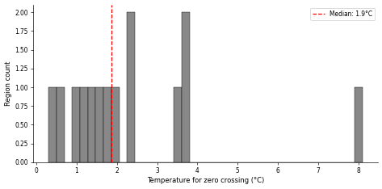

Figure 3: Distribution of Zero Crossing Temperatures

# 5 Slope Analysis

Maximum slope between 0 and 10°C: $\frac{dM}{dT} = \alpha + 2\beta T$

The maximum occurs at either T=0 or T=10 (endpoints of interval).

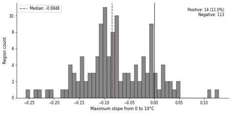

Figure 4: Distribution of Maximum Slopes (0-10°C)

*Convexity analysis omitted (beta constraint active).*

# 6 R-squared Analysis

## 6.1 Polynomial Fit Quality (rsqr1)

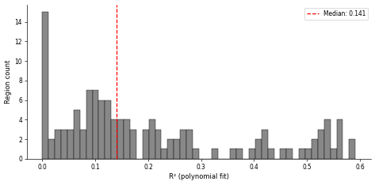

Figure 5: Regional Fit Quality (R-squared)

## 6.2 Error Model R-squared (rsqr2) Quantiles

Table 4: rsqr2 Quantiles

| 0% (Min) | 25% | 50% (Median) | 75% | 100% (Max) |
| --- | --- | --- | --- | --- |
| 0.0000 | 0.5189 | 0.5625 | 0.5904 | 0.6190 |

# 7 Modelled Variance

Modelled variance statistic: $1 - \frac{\sum_i \eta_i^2}{\sum_i D_i^2}$

Table 5: Modelled Variance Statistics

| Statistic | Value |
| --- | --- |
| Modelled variance | 0.7805 |
| Sum(η²) | 2.8522 |
| Sum(D²) at T=3.0°C | 12.9942 |
| N regions | 127 |

# 8 Best- and Worst-Fitting Regions

The 3 worst- and 3 best-fitting regions by R-squared, with raw simulation data overlaid on the fitted polynomial curve. **Red rows = worst fits**, **green rows = best fits**.

Table 6: Best- and worst-fitting regions

Top 3 best fit (R²) Top 3 worst fit (R²)

| Region | α | β | η | R² |
| --- | --- | --- | --- | --- |
| GRC | -0.145 | -0.0136 | 0.109 | 0.592 |
| ESP | -0.17 | -0.0133 | 0.122 | 0.586 |
| KAZ | -0.0982 | -0.00724 | 0.073 | 0.566 |
| COM | -0.0037 | -0.00134 | 0.174 | 0.00153 |
| BTN | 0.0261 | -0.00343 | 0.13 | 0.00543 |
| STP | 0.0153 | -9.45e-4 | 0.104 | 0.00572 |

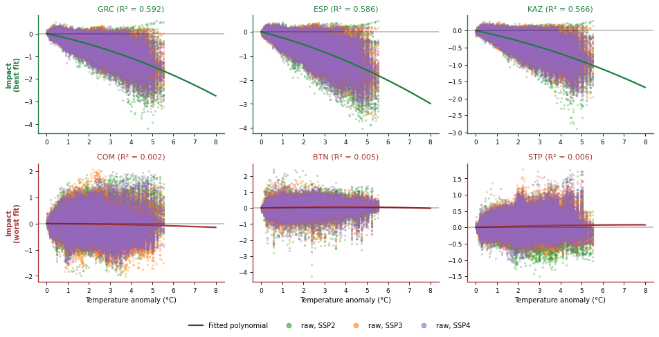

# 9 Regional Parameter Maps

Maps of key parameters at the **country** level. Red = negative (damage increases with T), Blue = positive.

## 9.1 Alpha (Linear Coefficient)

Alpha ($\alpha$) represents the linear sensitivity to temperature. Regions with negative alpha experience damage that increases with the first degree of warming.

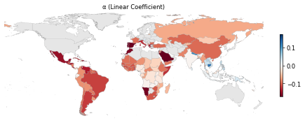

Figure 7: α (linear coefficient)

## 9.2 Beta (Quadratic Coefficient)

Beta ($\beta$) represents the curvature of the damage function.

The concavity ($\beta \leq 0$) constraint is enforced for this sector, meaning optimal temperature exists, damages accelerate beyond it.

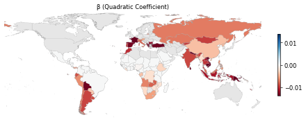

Figure 8: β (quadratic coefficient)

## 9.3 R-squared (Fit Quality)

$R^2$ measures the polynomial fit quality. Higher values indicate that the quadratic form captures more of the variance in the data.

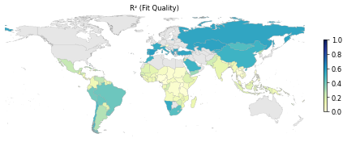

Figure 9: R² (stage 1 fit quality)

# 10 F2: Flex vs Raw Comparison

Comparison of flexible damage function predictions against raw simulation means.

For each scenario (RCP × SSP × Model), we compute at the final year:

- **Flex predicted**: $(\alpha \cdot T + \beta \cdot T^2) \cdot Y^\gamma$
- **Raw actual**: The outcome variable (y) from the source data

**Year 2098**: 1,457,280 rows

**rcp45**

**SSP2**

**high**

**Correlation:** 0.7075 | **RMSE:** 0.135804 | **Sign agreement:** 91.3%

[interactive chart not shown]

Top 5 best predicted Top 5 worst predicted

Year 2098 · T<sub>mean</sub> across these regions: 1.94°C

| Region | Raw | Flex | Residual |
| --- | --- | --- | --- |
| FJI | 0 | 0 | 0 |
| NGA | -0.0419 | -0.0422 | -3.30e-4 |
| PRI | -0.555 | -0.553 | 0.00139 |
| KEN | -0.0853 | -0.0832 | 0.002 |
| BRB | -0.569 | -0.565 | 0.00435 |
| SOM | 0.0324 | -0.305 | -0.338 |
| LCA | -0.0965 | -0.434 | -0.337 |
| TGO | -0.0502 | -0.382 | -0.332 |
| HND | -0.0836 | -0.373 | -0.289 |
| GRD | -0.0679 | -0.326 | -0.259 |

**low**

**Correlation:** 0.8567 | **RMSE:** 0.094995 | **Sign agreement:** 94.5%

[interactive chart not shown]

Top 5 best predicted Top 5 worst predicted

Year 2098 · T<sub>mean</sub> across these regions: 1.94°C

| Region | Raw | Flex | Residual |
| --- | --- | --- | --- |
| FJI | 0 | 0 | 0 |
| KEN | -0.0794 | -0.0818 | -0.00241 |
| VNM | 0.0131 | 0.0086 | -0.00445 |
| BTN | 0.0438 | 0.0511 | 0.00727 |
| TCD | -0.106 | -0.115 | -0.00836 |
| SOM | -0.0905 | -0.313 | -0.222 |
| CAF | 0.0168 | -0.203 | -0.22 |
| SLV | -0.203 | -0.423 | -0.219 |
| ISR | -0.884 | -0.67 | 0.215 |
| GIN | -0.0931 | -0.276 | -0.183 |

**SSP3**

**high**

**Correlation:** 0.8481 | **RMSE:** 0.107234 | **Sign agreement:** 90.6%

[interactive chart not shown]

Top 5 best predicted Top 5 worst predicted

Year 2098 · T<sub>mean</sub> across these regions: 1.94°C

| Region | Raw | Flex | Residual |
| --- | --- | --- | --- |
| FJI | 0 | 0 | 0 |
| GRC | -0.451 | -0.452 | -6.33e-4 |
| PRK | -0.0689 | -0.0705 | -0.00163 |
| BRB | -0.552 | -0.554 | -0.00186 |
| RUS | -0.204 | -0.208 | -0.00326 |
| TGO | -0.033 | -0.366 | -0.333 |
| GRD | -0.0878 | -0.32 | -0.232 |
| CAF | 0.0257 | -0.201 | -0.226 |
| LCA | -0.2 | -0.424 | -0.224 |
| HND | -0.14 | -0.361 | -0.221 |

**low**

**Correlation:** 0.7657 | **RMSE:** 0.120098 | **Sign agreement:** 94.5%

[interactive chart not shown]

Top 5 best predicted Top 5 worst predicted

Year 2098 · T<sub>mean</sub> across these regions: 1.94°C

| Region | Raw | Flex | Residual |
| --- | --- | --- | --- |
| FJI | 0 | 0 | 0 |
| ZAF | -0.306 | -0.306 | 3.97e-4 |
| AGO | -0.0529 | -0.0525 | 4.09e-4 |
| PRY | -0.245 | -0.244 | 9.19e-4 |
| BRB | -0.554 | -0.552 | 0.00154 |
| GNB | -0.653 | -0.182 | 0.471 |
| GIN | -0.685 | -0.259 | 0.425 |
| CIV | -0.643 | -0.249 | 0.394 |
| TTO | -0.255 | -0.623 | -0.368 |
| BFA | -0.618 | -0.254 | 0.364 |

**SSP4**

**high**

**Correlation:** 0.7876 | **RMSE:** 0.108907 | **Sign agreement:** 92.9%

[interactive chart not shown]

Top 5 best predicted Top 5 worst predicted

Year 2098 · T<sub>mean</sub> across these regions: 1.94°C

| Region | Raw | Flex | Residual |
| --- | --- | --- | --- |
| FJI | 0 | 0 | 0 |
| MAC | -0.166 | -0.165 | 4.52e-4 |
| PSE | -0.414 | -0.42 | -0.00567 |
| NCL | -0.158 | -0.152 | 0.00582 |
| PRT | -0.546 | -0.54 | 0.00596 |
| SOM | -0.697 | -0.278 | 0.419 |
| TTO | -0.257 | -0.624 | -0.367 |
| BRB | -0.229 | -0.565 | -0.336 |
| PRI | -0.274 | -0.554 | -0.281 |
| LCA | -0.164 | -0.434 | -0.269 |

**low**

**Correlation:** 0.9301 | **RMSE:** 0.067595 | **Sign agreement:** 92.9%

[interactive chart not shown]

Top 5 best predicted Top 5 worst predicted

Year 2098 · T<sub>mean</sub> across these regions: 1.94°C

| Region | Raw | Flex | Residual |
| --- | --- | --- | --- |
| FJI | 0 | 0 | 0 |
| NPL | 0.196 | 0.196 | 3.24e-4 |
| SLB | -0.0304 | -0.0297 | 6.96e-4 |
| SMR | -0.237 | -0.238 | -8.25e-4 |
| IND | -0.0569 | -0.056 | 9.32e-4 |
| SOM | -0.0682 | -0.303 | -0.235 |
| MMR | -0.357 | -0.183 | 0.174 |
| ISR | -0.818 | -0.665 | 0.153 |
| ZWE | -0.115 | -0.263 | -0.148 |
| LKA | 0.105 | -0.0323 | -0.137 |

**rcp85**

**SSP2**

**high**

**Correlation:** 0.8506 | **RMSE:** 0.186660 | **Sign agreement:** 95.3%

[interactive chart not shown]

Top 5 best predicted Top 5 worst predicted

Year 2098 · T<sub>mean</sub> across these regions: 4.17°C

| Region | Raw | Flex | Residual |
| --- | --- | --- | --- |
| FJI | 0 | 0 | 0 |
| HKG | -0.409 | -0.41 | -9.52e-4 |
| COD | -0.176 | -0.168 | 0.00815 |
| VNM | -0.156 | -0.166 | -0.0103 |
| MAC | -0.344 | -0.356 | -0.0114 |
| LCA | -0.418 | -0.932 | -0.514 |
| TGO | -0.314 | -0.821 | -0.507 |
| SOM | -0.168 | -0.656 | -0.488 |
| SLV | -0.495 | -0.917 | -0.422 |
| HND | -0.402 | -0.8 | -0.399 |

**low**

**Correlation:** 0.9136 | **RMSE:** 0.149750 | **Sign agreement:** 93.7%

[interactive chart not shown]

Top 5 best predicted Top 5 worst predicted

Year 2098 · T<sub>mean</sub> across these regions: 4.17°C

| Region | Raw | Flex | Residual |
| --- | --- | --- | --- |
| FJI | 0 | 0 | 0 |
| RUS | -0.546 | -0.539 | 0.00651 |
| PER | -0.592 | -0.585 | 0.00695 |
| JOR | -0.466 | -0.476 | -0.0103 |
| TLS | -0.267 | -0.278 | -0.0107 |
| CAF | 0.0287 | -0.436 | -0.465 |
| SOM | -0.253 | -0.672 | -0.419 |
| TGO | -0.36 | -0.779 | -0.419 |
| SLV | -0.495 | -0.908 | -0.413 |
| BLZ | -0.534 | -0.833 | -0.299 |

**SSP3**

**high**

**Correlation:** 0.9247 | **RMSE:** 0.157691 | **Sign agreement:** 96.9%

[interactive chart not shown]

Top 5 best predicted Top 5 worst predicted

Year 2098 · T<sub>mean</sub> across these regions: 4.17°C

| Region | Raw | Flex | Residual |
| --- | --- | --- | --- |
| FJI | 0 | 0 | 0 |
| KEN | -0.171 | -0.173 | -0.00246 |
| SSD | -0.203 | -0.199 | 0.00356 |
| TUR | -0.851 | -0.856 | -0.00543 |
| PNG | -0.143 | -0.157 | -0.0137 |
| TGO | -0.199 | -0.786 | -0.587 |
| ISR | -0.951 | -1.45 | -0.501 |
| CAF | 0.00449 | -0.431 | -0.435 |
| LCA | -0.52 | -0.911 | -0.39 |
| TTO | -0.955 | -1.32 | -0.365 |

**low**

**Correlation:** 0.7881 | **RMSE:** 0.230749 | **Sign agreement:** 98.4%

[interactive chart not shown]

Top 5 best predicted Top 5 worst predicted

Year 2098 · T<sub>mean</sub> across these regions: 4.17°C

| Region | Raw | Flex | Residual |
| --- | --- | --- | --- |
| FJI | 0 | 0 | 0 |
| IDN | -0.226 | -0.226 | 1.35e-5 |
| GRD | -0.681 | -0.68 | 2.13e-4 |
| IND | -0.232 | -0.232 | -2.26e-4 |
| REU | -0.0178 | -0.0188 | -0.00104 |
| GIN | -1.34 | -0.557 | 0.778 |
| TTO | -0.644 | -1.34 | -0.696 |
| GNB | -1.08 | -0.39 | 0.691 |
| TGO | -1.4 | -0.745 | 0.654 |
| CIV | -1.14 | -0.535 | 0.604 |

**SSP4**

**high**

**Correlation:** 0.8429 | **RMSE:** 0.194028 | **Sign agreement:** 96.9%

[interactive chart not shown]

Top 5 best predicted Top 5 worst predicted

Year 2098 · T<sub>mean</sub> across these regions: 4.17°C

| Region | Raw | Flex | Residual |
| --- | --- | --- | --- |
| FJI | 0 | 0 | 0 |
| LAO | 0.0306 | 0.0293 | -0.0013 |
| PRK | -0.211 | -0.208 | 0.0033 |
| MTQ | -0.575 | -0.569 | 0.00607 |
| GLP | -0.587 | -0.593 | -0.00643 |
| SOM | -1.63 | -0.596 | 1.03 |
| TTO | -0.633 | -1.34 | -0.709 |
| BRB | -0.595 | -1.21 | -0.619 |
| MMR | -1.03 | -0.419 | 0.612 |
| ISR | -0.941 | -1.47 | -0.529 |

**low**

**Correlation:** 0.9529 | **RMSE:** 0.106219 | **Sign agreement:** 100.0%

[interactive chart not shown]

Top 5 best predicted Top 5 worst predicted

Year 2098 · T<sub>mean</sub> across these regions: 4.17°C

| Region | Raw | Flex | Residual |
| --- | --- | --- | --- |
| FJI | 0 | 0 | 0 |
| IDN | -0.224 | -0.225 | -0.00114 |
| PAN | -0.421 | -0.419 | 0.00179 |
| BDI | -0.0327 | -0.0307 | 0.00207 |
| SSD | -0.196 | -0.198 | -0.00281 |
| MMR | -1.01 | -0.419 | 0.592 |
| SOM | -0.289 | -0.652 | -0.363 |
| BFA | -0.835 | -0.554 | 0.28 |
| FRA | -1.1 | -0.907 | 0.195 |
| MAR | -0.914 | -1.1 | -0.187 |

## 10.1 Scenario Summary

Table 7: Fit statistics across all 12 scenarios

| RCP | SSP | Model | N | Corr | RMSE | Sign% |
| --- | --- | --- | --- | --- | --- | --- |
| rcp45 | SSP2 | high | 127 | 0.7075 | 0.135804 | 91.3% |
| rcp45 | SSP2 | low | 127 | 0.8567 | 0.094995 | 94.5% |
| rcp45 | SSP3 | high | 127 | 0.8481 | 0.107234 | 90.6% |
| rcp45 | SSP3 | low | 127 | 0.7657 | 0.120098 | 94.5% |
| rcp45 | SSP4 | high | 127 | 0.7876 | 0.108907 | 92.9% |
| rcp45 | SSP4 | low | 127 | 0.9301 | 0.067595 | 92.9% |
| rcp85 | SSP2 | high | 127 | 0.8506 | 0.18666 | 95.3% |
| rcp85 | SSP2 | low | 127 | 0.9136 | 0.14975 | 93.7% |
| rcp85 | SSP3 | high | 127 | 0.9247 | 0.157691 | 96.9% |
| rcp85 | SSP3 | low | 127 | 0.7881 | 0.230749 | 98.4% |
| rcp85 | SSP4 | high | 127 | 0.8429 | 0.194028 | 96.9% |
| rcp85 | SSP4 | low | 127 | 0.9529 | 0.106219 | 100.0% |

# 11 Data Reference

## 11.1 File Locations

| Item | Path |
| --- | --- |
| Regional CSV | `/project/cil/gcp/flex_damage_funcs/parameters/agriculture__cassava_country__regional_parameters.csv` |
| Global JSON | `/project/cil/gcp/flex_damage_funcs/parameters/agriculture__cassava_country__global_results.json` |
| Metadata JSON | `/project/cil/gcp/flex_damage_funcs/parameters/agriculture__cassava_country__metadata.json` |

## 11.2 Column Definitions

| Column | Description |
| --- | --- |
| `region` | Region identifier (hierarchical code, first 3 chars = country ISO3) |
| `gamma` | Income elasticity quantile value |
| `alpha` | Linear temperature coefficient |
| `beta` | Quadratic temperature coefficient |
| `sigma11` | Var(alpha) |
| `sigma12` | Cov(alpha, beta) |
| `sigma22` | Var(beta) |
| `rho` | Correlation with global residual process |
| `zeta` | Temperature-dependent heteroskedasticity |
| `eta` | Residual standard deviation |
| `rsqr1` | R-squared of polynomial fit |
| `rsqr2` | R-squared of error model |

*Report generated with FlexDamage v1.0.0*